# Risk Factor Analysis

## Outcome Variable

**Outcome Variable:** ever_stunted

## Predictor Variables

**Intervention Variable:** single

**Adjustment Set:**

unadjusted

## Stratifying Variables

The analysis was stratified on these variable(s):

- agecat
- studyid

The following strata were considered:

- agecat: 12 months, studyid: ki0047075b-MAL-ED
- agecat: 12 months, studyid: ki1066203-TanzaniaChild2
- agecat: 12 months, studyid: ki1112895-Guatemala BSC
- agecat: 12 months, studyid: ki1126311-ZVITAMBO
- agecat: 12 months, studyid: ki1135781-COHORTS
- agecat: 18 months, studyid: ki0047075b-MAL-ED
- agecat: 18 months, studyid: ki1066203-TanzaniaChild2
- agecat: 18 months, studyid: ki1112895-Guatemala BSC
- agecat: 18 months, studyid: ki1126311-ZVITAMBO
- agecat: 18 months, studyid: ki1135781-COHORTS
- agecat: 24 months, studyid: ki0047075b-MAL-ED
- agecat: 24 months, studyid: ki1066203-TanzaniaChild2
- agecat: 24 months, studyid: ki1126311-ZVITAMBO
- agecat: 24 months, studyid: ki1135781-COHORTS
- agecat: 3 months, studyid: ki0047075b-MAL-ED
- agecat: 3 months, studyid: ki1066203-TanzaniaChild2
- agecat: 3 months, studyid: ki1126311-ZVITAMBO
- agecat: 3 months, studyid: ki1135781-COHORTS
- agecat: 6 months, studyid: ki0047075b-MAL-ED
- agecat: 6 months, studyid: ki1066203-TanzaniaChild2
- agecat: 6 months, studyid: ki1112895-Guatemala BSC
- agecat: 6 months, studyid: ki1126311-ZVITAMBO
- agecat: 6 months, studyid: ki1135781-COHORTS

### Dropped Strata

Some strata were dropped due to rare outcomes:

- agecat: 6 months, studyid: ki1112895-Guatemala BSC
- agecat: 12 months, studyid: ki1112895-Guatemala BSC
- agecat: 18 months, studyid: ki1112895-Guatemala BSC

## Methods Detail

We’re interested in the causal parameters $E[Y_a]$ for all values of $a \in \mathcal{A}$. These parameters represent the mean outcome if, possibly contrary to fact, we intervened to set all units to have $A=a$. Under the randomization and positivity assumptions, these are identified by the statistical parameters $\psi_a=E_W[E_{Y|A,W}(Y|A=a,W)]$. In addition, we’re interested in the mean of $Y$, $E[Y]$ under no intervention (the observed mean). We will estimate these parameters by using SuperLearner to fit the relevant likelihood factors – $E_{Y|A,W}(Y|A=a,W)$ and $p(A=a|W)$, and then updating our likelihood fit using a joint TMLE.

For unadjusted analyses ($W=\{\}$), initial likelihoods were estimated using Lrnr_glm to estimate the simple $E(Y|A)$ and Lrnr_mean to estimate $p(A)$. For adjusted analyses, a small library containing Lrnr_glmnet, Lrnr_xgboost, and Lrnr_mean was used.

Having estimated these parameters, we will then use the delta method to estimate relative risks and attributable risks relative to a prespecified baseline level of $A$.

# Results Detail

## Results Plots

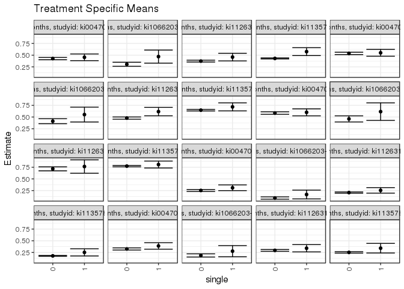

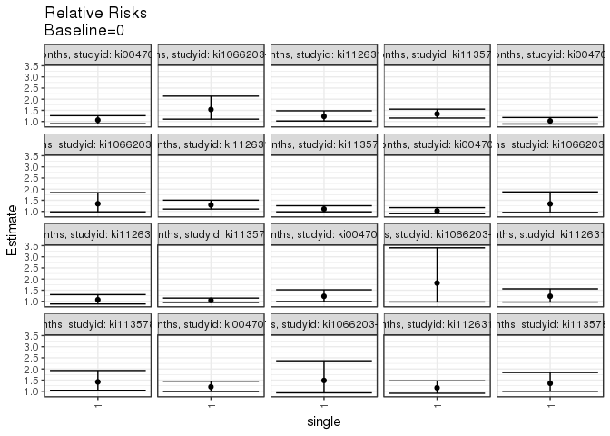

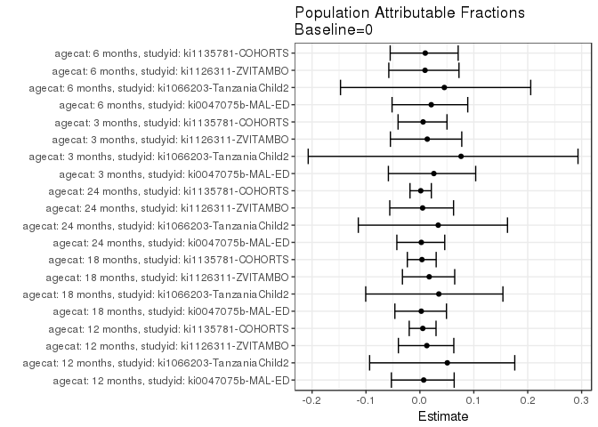

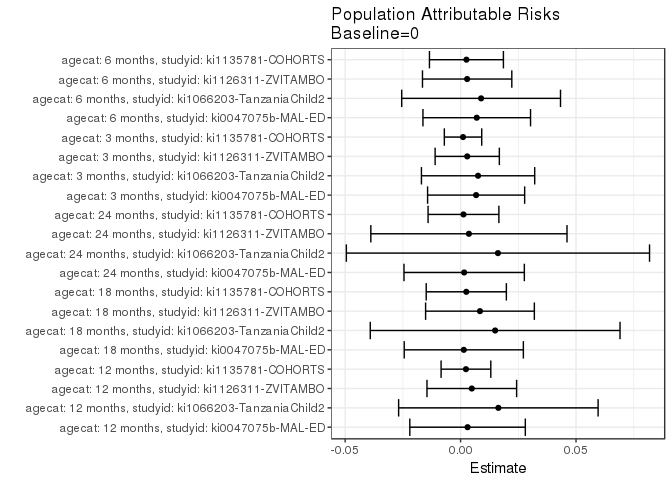

## Data Summary

| agecat | studyid | A | n | nA | nAY0 | nAY1 |
| --- | --- | --- | --- | --- | --- | --- |
| 3 months | ki0047075b-MAL-ED | 0 | 1866 | 1647 | 1230 | 417 |
| 3 months | ki0047075b-MAL-ED | 1 | 1866 | 219 | 151 | 68 |
| 3 months | ki1066203-TanzaniaChild2 | 0 | 595 | 535 | 486 | 49 |
| 3 months | ki1066203-TanzaniaChild2 | 1 | 595 | 60 | 50 | 10 |
| 3 months | ki1112895-Guatemala BSC | 0 | 0 | 0 | 0 | 0 |
| 3 months | ki1112895-Guatemala BSC | 1 | 0 | 0 | 0 | 0 |
| 3 months | ki1126311-ZVITAMBO | 0 | 3480 | 3268 | 2590 | 678 |
| 3 months | ki1126311-ZVITAMBO | 1 | 3480 | 212 | 158 | 54 |
| 3 months | ki1135781-COHORTS | 0 | 8678 | 8555 | 7037 | 1518 |
| 3 months | ki1135781-COHORTS | 1 | 8678 | 123 | 92 | 31 |
| 6 months | ki0047075b-MAL-ED | 0 | 1746 | 1556 | 1050 | 506 |
| 6 months | ki0047075b-MAL-ED | 1 | 1746 | 190 | 116 | 74 |
| 6 months | ki1066203-TanzaniaChild2 | 0 | 551 | 497 | 404 | 93 |
| 6 months | ki1066203-TanzaniaChild2 | 1 | 551 | 54 | 39 | 15 |
| 6 months | ki1112895-Guatemala BSC | 0 | 90 | 84 | 61 | 23 |
| 6 months | ki1112895-Guatemala BSC | 1 | 90 | 6 | 3 | 3 |
| 6 months | ki1126311-ZVITAMBO | 0 | 2276 | 2135 | 1506 | 629 |
| 6 months | ki1126311-ZVITAMBO | 1 | 2276 | 141 | 93 | 48 |
| 6 months | ki1135781-COHORTS | 0 | 2906 | 2824 | 2113 | 711 |
| 6 months | ki1135781-COHORTS | 1 | 2906 | 82 | 54 | 28 |
| 12 months | ki0047075b-MAL-ED | 0 | 1688 | 1503 | 862 | 641 |
| 12 months | ki0047075b-MAL-ED | 1 | 1688 | 185 | 101 | 84 |
| 12 months | ki1066203-TanzaniaChild2 | 0 | 491 | 442 | 307 | 135 |
| 12 months | ki1066203-TanzaniaChild2 | 1 | 491 | 49 | 26 | 23 |
| 12 months | ki1112895-Guatemala BSC | 0 | 80 | 74 | 42 | 32 |
| 12 months | ki1112895-Guatemala BSC | 1 | 80 | 6 | 2 | 4 |
| 12 months | ki1126311-ZVITAMBO | 0 | 2533 | 2389 | 1498 | 891 |
| 12 months | ki1126311-ZVITAMBO | 1 | 2533 | 144 | 78 | 66 |
| 12 months | ki1135781-COHORTS | 0 | 8270 | 8138 | 4636 | 3502 |
| 12 months | ki1135781-COHORTS | 1 | 8270 | 132 | 56 | 76 |
| 18 months | ki0047075b-MAL-ED | 0 | 1613 | 1435 | 663 | 772 |
| 18 months | ki0047075b-MAL-ED | 1 | 1613 | 178 | 80 | 98 |
| 18 months | ki1066203-TanzaniaChild2 | 0 | 359 | 321 | 189 | 132 |
| 18 months | ki1066203-TanzaniaChild2 | 1 | 359 | 38 | 17 | 21 |
| 18 months | ki1112895-Guatemala BSC | 0 | 49 | 46 | 23 | 23 |
| 18 months | ki1112895-Guatemala BSC | 1 | 49 | 3 | 0 | 3 |
| 18 months | ki1126311-ZVITAMBO | 0 | 1848 | 1736 | 907 | 829 |
| 18 months | ki1126311-ZVITAMBO | 1 | 1848 | 112 | 43 | 69 |
| 18 months | ki1135781-COHORTS | 0 | 3023 | 2917 | 1031 | 1886 |
| 18 months | ki1135781-COHORTS | 1 | 3023 | 106 | 30 | 76 |
| 24 months | ki0047075b-MAL-ED | 0 | 1538 | 1373 | 569 | 804 |
| 24 months | ki0047075b-MAL-ED | 1 | 1538 | 165 | 66 | 99 |
| 24 months | ki1066203-TanzaniaChild2 | 0 | 250 | 224 | 121 | 103 |
| 24 months | ki1066203-TanzaniaChild2 | 1 | 250 | 26 | 10 | 16 |
| 24 months | ki1112895-Guatemala BSC | 0 | 0 | 0 | 0 | 0 |
| 24 months | ki1112895-Guatemala BSC | 1 | 0 | 0 | 0 | 0 |
| 24 months | ki1126311-ZVITAMBO | 0 | 469 | 435 | 124 | 311 |
| 24 months | ki1126311-ZVITAMBO | 1 | 469 | 34 | 8 | 26 |
| 24 months | ki1135781-COHORTS | 0 | 2975 | 2866 | 650 | 2216 |
| 24 months | ki1135781-COHORTS | 1 | 2975 | 109 | 21 | 88 |

## Results Table

### Parameter: TSM

| agecat | studyid | intervention_level | baseline_level | estimate | ci_lower | ci_upper |
| --- | --- | --- | --- | --- | --- | --- |
| 3 months | ki0047075b-MAL-ED | 0 | NA | 0.2531876 | 0.2321816 | 0.2741937 |
| 3 months | ki0047075b-MAL-ED | 1 | NA | 0.3105023 | 0.2492050 | 0.3717996 |
| 3 months | ki1066203-TanzaniaChild2 | 0 | NA | 0.0915888 | 0.0671264 | 0.1160512 |
| 3 months | ki1066203-TanzaniaChild2 | 1 | NA | 0.1666667 | 0.0722885 | 0.2610448 |
| 3 months | ki1126311-ZVITAMBO | 0 | NA | 0.2074663 | 0.1935619 | 0.2213707 |
| 3 months | ki1126311-ZVITAMBO | 1 | NA | 0.2547170 | 0.1960583 | 0.3133756 |
| 3 months | ki1135781-COHORTS | 0 | NA | 0.1774401 | 0.1693441 | 0.1855361 |
| 3 months | ki1135781-COHORTS | 1 | NA | 0.2520325 | 0.1752981 | 0.3287669 |
| 6 months | ki0047075b-MAL-ED | 0 | NA | 0.3251928 | 0.3019104 | 0.3484752 |
| 6 months | ki0047075b-MAL-ED | 1 | NA | 0.3894737 | 0.3201172 | 0.4588301 |
| 6 months | ki1066203-TanzaniaChild2 | 0 | NA | 0.1871227 | 0.1528033 | 0.2214422 |
| 6 months | ki1066203-TanzaniaChild2 | 1 | NA | 0.2777778 | 0.1582057 | 0.3973499 |
| 6 months | ki1126311-ZVITAMBO | 0 | NA | 0.2946136 | 0.2752723 | 0.3139548 |
| 6 months | ki1126311-ZVITAMBO | 1 | NA | 0.3404255 | 0.2621949 | 0.4186562 |
| 6 months | ki1135781-COHORTS | 0 | NA | 0.2517705 | 0.2357598 | 0.2677812 |
| 6 months | ki1135781-COHORTS | 1 | NA | 0.3414634 | 0.2388089 | 0.4441179 |
| 12 months | ki0047075b-MAL-ED | 0 | NA | 0.4264804 | 0.4014700 | 0.4514908 |
| 12 months | ki0047075b-MAL-ED | 1 | NA | 0.4540541 | 0.3822879 | 0.5258202 |
| 12 months | ki1066203-TanzaniaChild2 | 0 | NA | 0.3054299 | 0.2624472 | 0.3484125 |
| 12 months | ki1066203-TanzaniaChild2 | 1 | NA | 0.4693878 | 0.3295104 | 0.6092651 |
| 12 months | ki1126311-ZVITAMBO | 0 | NA | 0.3729594 | 0.3535637 | 0.3923550 |
| 12 months | ki1126311-ZVITAMBO | 1 | NA | 0.4583333 | 0.3769362 | 0.5397305 |
| 12 months | ki1135781-COHORTS | 0 | NA | 0.4303269 | 0.4195690 | 0.4410848 |
| 12 months | ki1135781-COHORTS | 1 | NA | 0.5757576 | 0.4914407 | 0.6600744 |
| 18 months | ki0047075b-MAL-ED | 0 | NA | 0.5379791 | 0.5121761 | 0.5637821 |
| 18 months | ki0047075b-MAL-ED | 1 | NA | 0.5505618 | 0.4774629 | 0.6236607 |
| 18 months | ki1066203-TanzaniaChild2 | 0 | NA | 0.4112150 | 0.3573118 | 0.4651181 |
| 18 months | ki1066203-TanzaniaChild2 | 1 | NA | 0.5526316 | 0.3943201 | 0.7109431 |
| 18 months | ki1126311-ZVITAMBO | 0 | NA | 0.4775346 | 0.4540316 | 0.5010375 |
| 18 months | ki1126311-ZVITAMBO | 1 | NA | 0.6160714 | 0.5259771 | 0.7061657 |
| 18 months | ki1135781-COHORTS | 0 | NA | 0.6465547 | 0.6292040 | 0.6639053 |
| 18 months | ki1135781-COHORTS | 1 | NA | 0.7169811 | 0.6312125 | 0.8027498 |
| 24 months | ki0047075b-MAL-ED | 0 | NA | 0.5855790 | 0.5595134 | 0.6116446 |
| 24 months | ki0047075b-MAL-ED | 1 | NA | 0.6000000 | 0.5252256 | 0.6747744 |
| 24 months | ki1066203-TanzaniaChild2 | 0 | NA | 0.4598214 | 0.3944244 | 0.5252184 |
| 24 months | ki1066203-TanzaniaChild2 | 1 | NA | 0.6153846 | 0.4280067 | 0.8027625 |
| 24 months | ki1126311-ZVITAMBO | 0 | NA | 0.7149425 | 0.6724739 | 0.7574112 |
| 24 months | ki1126311-ZVITAMBO | 1 | NA | 0.7647059 | 0.6219727 | 0.9074390 |
| 24 months | ki1135781-COHORTS | 0 | NA | 0.7732031 | 0.7578693 | 0.7885368 |
| 24 months | ki1135781-COHORTS | 1 | NA | 0.8073394 | 0.7332882 | 0.8813907 |

### Parameter: E(Y)

| agecat | studyid | intervention_level | baseline_level | estimate | ci_lower | ci_upper |
| --- | --- | --- | --- | --- | --- | --- |
| 3 months | ki0047075b-MAL-ED | NA | NA | 0.2599143 | 0.2590771 | 0.2607515 |
| 3 months | ki1066203-TanzaniaChild2 | NA | NA | 0.0991597 | 0.0973416 | 0.1009777 |
| 3 months | ki1126311-ZVITAMBO | NA | NA | 0.2103448 | 0.2099693 | 0.2107204 |
| 3 months | ki1135781-COHORTS | NA | NA | 0.1784973 | 0.1783118 | 0.1786829 |
| 6 months | ki0047075b-MAL-ED | NA | NA | 0.3321879 | 0.3312486 | 0.3331271 |
| 6 months | ki1066203-TanzaniaChild2 | NA | NA | 0.1960073 | 0.1937547 | 0.1982598 |
| 6 months | ki1126311-ZVITAMBO | NA | NA | 0.2974517 | 0.2969979 | 0.2979055 |
| 6 months | ki1135781-COHORTS | NA | NA | 0.2543014 | 0.2537613 | 0.2548415 |
| 12 months | ki0047075b-MAL-ED | NA | NA | 0.4295024 | 0.4290913 | 0.4299134 |
| 12 months | ki1066203-TanzaniaChild2 | NA | NA | 0.3217923 | 0.3174411 | 0.3261435 |
| 12 months | ki1126311-ZVITAMBO | NA | NA | 0.3778129 | 0.3770429 | 0.3785829 |
| 12 months | ki1135781-COHORTS | NA | NA | 0.4326481 | 0.4322553 | 0.4330410 |
| 18 months | ki0047075b-MAL-ED | NA | NA | 0.5393676 | 0.5391752 | 0.5395601 |
| 18 months | ki1066203-TanzaniaChild2 | NA | NA | 0.4261838 | 0.4216772 | 0.4306905 |
| 18 months | ki1126311-ZVITAMBO | NA | NA | 0.4859307 | 0.4844232 | 0.4874383 |
| 18 months | ki1135781-COHORTS | NA | NA | 0.6490241 | 0.6485623 | 0.6494860 |
| 24 months | ki0047075b-MAL-ED | NA | NA | 0.5871261 | 0.5869030 | 0.5873493 |
| 24 months | ki1066203-TanzaniaChild2 | NA | NA | 0.4760000 | 0.4701017 | 0.4818983 |
| 24 months | ki1126311-ZVITAMBO | NA | NA | 0.7185501 | 0.7173810 | 0.7197192 |
| 24 months | ki1135781-COHORTS | NA | NA | 0.7744538 | 0.7742233 | 0.7746843 |

### Parameter: RR

| agecat | studyid | intervention_level | baseline_level | estimate | ci_lower | ci_upper |
| --- | --- | --- | --- | --- | --- | --- |
| 3 months | ki0047075b-MAL-ED | 1 | 0 | 1.226372 | 0.9899723 | 1.519224 |
| 3 months | ki1066203-TanzaniaChild2 | 1 | 0 | 1.819728 | 0.9729624 | 3.403430 |
| 3 months | ki1126311-ZVITAMBO | 1 | 0 | 1.227751 | 0.9659341 | 1.560533 |
| 3 months | ki1135781-COHORTS | 1 | 0 | 1.420381 | 1.0440035 | 1.932447 |
| 6 months | ki0047075b-MAL-ED | 1 | 0 | 1.197670 | 0.9885135 | 1.451081 |
| 6 months | ki1066203-TanzaniaChild2 | 1 | 0 | 1.484468 | 0.9297437 | 2.370165 |
| 6 months | ki1126311-ZVITAMBO | 1 | 0 | 1.155498 | 0.9098603 | 1.467452 |
| 6 months | ki1135781-COHORTS | 1 | 0 | 1.356248 | 0.9974425 | 1.844126 |
| 12 months | ki0047075b-MAL-ED | 1 | 0 | 1.064654 | 0.8994830 | 1.260155 |
| 12 months | ki1066203-TanzaniaChild2 | 1 | 0 | 1.536810 | 1.1053383 | 2.136709 |
| 12 months | ki1126311-ZVITAMBO | 1 | 0 | 1.228910 | 1.0212993 | 1.478723 |
| 12 months | ki1135781-COHORTS | 1 | 0 | 1.337954 | 1.1532432 | 1.552249 |
| 18 months | ki0047075b-MAL-ED | 1 | 0 | 1.023389 | 0.8886520 | 1.178554 |
| 18 months | ki1066203-TanzaniaChild2 | 1 | 0 | 1.343900 | 0.9807289 | 1.841555 |
| 18 months | ki1126311-ZVITAMBO | 1 | 0 | 1.290109 | 1.1056423 | 1.505351 |
| 18 months | ki1135781-COHORTS | 1 | 0 | 1.108926 | 0.9809772 | 1.253562 |
| 24 months | ki0047075b-MAL-ED | 1 | 0 | 1.024627 | 0.8976219 | 1.169602 |
| 24 months | ki1066203-TanzaniaChild2 | 1 | 0 | 1.338312 | 0.9563250 | 1.872877 |
| 24 months | ki1126311-ZVITAMBO | 1 | 0 | 1.069605 | 0.8793377 | 1.301041 |
| 24 months | ki1135781-COHORTS | 1 | 0 | 1.044149 | 0.9506213 | 1.146879 |

### Parameter: PAR

| agecat | studyid | intervention_level | baseline_level | estimate | ci_lower | ci_upper |
| --- | --- | --- | --- | --- | --- | --- |
| 3 months | ki0047075b-MAL-ED | 0 | NA | 0.0067266 | -0.0142961 | 0.0277494 |
| 3 months | ki1066203-TanzaniaChild2 | 0 | NA | 0.0075709 | -0.0169590 | 0.0321007 |
| 3 months | ki1126311-ZVITAMBO | 0 | NA | 0.0028785 | -0.0110310 | 0.0167880 |
| 3 months | ki1135781-COHORTS | 0 | NA | 0.0010573 | -0.0070409 | 0.0091554 |
| 6 months | ki0047075b-MAL-ED | 0 | NA | 0.0069951 | -0.0163063 | 0.0302964 |
| 6 months | ki1066203-TanzaniaChild2 | 0 | NA | 0.0088845 | -0.0255088 | 0.0432778 |
| 6 months | ki1126311-ZVITAMBO | 0 | NA | 0.0028381 | -0.0165085 | 0.0221847 |
| 6 months | ki1135781-COHORTS | 0 | NA | 0.0025309 | -0.0134889 | 0.0185507 |
| 12 months | ki0047075b-MAL-ED | 0 | NA | 0.0030220 | -0.0219918 | 0.0280358 |
| 12 months | ki1066203-TanzaniaChild2 | 0 | NA | 0.0163624 | -0.0268400 | 0.0595648 |
| 12 months | ki1126311-ZVITAMBO | 0 | NA | 0.0048535 | -0.0145575 | 0.0242644 |
| 12 months | ki1135781-COHORTS | 0 | NA | 0.0023213 | -0.0084438 | 0.0130863 |
| 18 months | ki0047075b-MAL-ED | 0 | NA | 0.0013885 | -0.0244152 | 0.0271923 |
| 18 months | ki1066203-TanzaniaChild2 | 0 | NA | 0.0149689 | -0.0391223 | 0.0690601 |
| 18 months | ki1126311-ZVITAMBO | 0 | NA | 0.0083962 | -0.0151551 | 0.0319474 |
| 18 months | ki1135781-COHORTS | 0 | NA | 0.0024695 | -0.0148873 | 0.0198263 |
| 24 months | ki0047075b-MAL-ED | 0 | NA | 0.0015471 | -0.0245194 | 0.0276137 |
| 24 months | ki1066203-TanzaniaChild2 | 0 | NA | 0.0161786 | -0.0494839 | 0.0818410 |
| 24 months | ki1126311-ZVITAMBO | 0 | NA | 0.0036076 | -0.0388772 | 0.0460923 |
| 24 months | ki1135781-COHORTS | 0 | NA | 0.0012507 | -0.0140848 | 0.0165862 |

### Parameter: PAF

| agecat | studyid | intervention_level | baseline_level | estimate | ci_lower | ci_upper |
| --- | --- | --- | --- | --- | --- | --- |
| 3 months | ki0047075b-MAL-ED | 0 | NA | 0.0258802 | -0.0584524 | 0.1034937 |
| 3 months | ki1066203-TanzaniaChild2 | 0 | NA | 0.0763504 | -0.2071901 | 0.2932939 |
| 3 months | ki1126311-ZVITAMBO | 0 | NA | 0.0136846 | -0.0547088 | 0.0776430 |
| 3 months | ki1135781-COHORTS | 0 | NA | 0.0059231 | -0.0404965 | 0.0502718 |
| 6 months | ki0047075b-MAL-ED | 0 | NA | 0.0210575 | -0.0516592 | 0.0887463 |
| 6 months | ki1066203-TanzaniaChild2 | 0 | NA | 0.0453275 | -0.1472626 | 0.2055877 |
| 6 months | ki1126311-ZVITAMBO | 0 | NA | 0.0095413 | -0.0576824 | 0.0724925 |
| 6 months | ki1135781-COHORTS | 0 | NA | 0.0099524 | -0.0550895 | 0.0709848 |
| 12 months | ki0047075b-MAL-ED | 0 | NA | 0.0070360 | -0.0529447 | 0.0636000 |
| 12 months | ki1066203-TanzaniaChild2 | 0 | NA | 0.0508477 | -0.0932890 | 0.1759818 |
| 12 months | ki1126311-ZVITAMBO | 0 | NA | 0.0128462 | -0.0398903 | 0.0629083 |
| 12 months | ki1135781-COHORTS | 0 | NA | 0.0053652 | -0.0198302 | 0.0299383 |
| 18 months | ki0047075b-MAL-ED | 0 | NA | 0.0025744 | -0.0464322 | 0.0492859 |
| 18 months | ki1066203-TanzaniaChild2 | 0 | NA | 0.0351231 | -0.1004880 | 0.1540231 |
| 18 months | ki1126311-ZVITAMBO | 0 | NA | 0.0172785 | -0.0323991 | 0.0645658 |
| 18 months | ki1135781-COHORTS | 0 | NA | 0.0038049 | -0.0233001 | 0.0301920 |
| 24 months | ki0047075b-MAL-ED | 0 | NA | 0.0026351 | -0.0427648 | 0.0460583 |
| 24 months | ki1066203-TanzaniaChild2 | 0 | NA | 0.0339886 | -0.1142502 | 0.1625058 |
| 24 months | ki1126311-ZVITAMBO | 0 | NA | 0.0050206 | -0.0558969 | 0.0624237 |
| 24 months | ki1135781-COHORTS | 0 | NA | 0.0016150 | -0.0183844 | 0.0212215 |